# Assignment 2

In this assignment you will create a coordinate-based multilayer perceptron in numpy from scratch. For each input image coordinate $(x,y)$, the model predicts the associated color $(r,g,b)$.

[figure not shown]

You will then compare the following input feature mappings $\gamma (\mathbf{v})$.

- No mapping: $\gamma(\mathbf{v})= \mathbf{v}$.
- Basic mapping: $\gamma(\mathbf{v})=\left[ \cos(2 \pi \mathbf{v}),\sin(2 \pi \mathbf{v}) \right]^\mathrm{T}$.
- Gaussian Fourier feature mapping: $\gamma(\mathbf{v})= \left[ \cos(2 \pi \mathbf B \mathbf{v}), \sin(2 \pi \mathbf B \mathbf{v}) \right]^\mathrm{T}$, where each entry in $\mathbf B \in \mathbb R^{m \times d}$ is sampled from $\mathcal N(0,\sigma^2)$.

Some notes to help you with that:

- You will implement the mappings in the helper functions `get_B_dict` and `input_mapping`.
- The basic mapping can be considered a case where $\mathbf B \in \mathbb R^{2 \times 2}$ is the indentity matrix.
- For this assignment, $d$ is 2 because the input coordinates in two dimensions.
- You can experiment with $m$, like $m=256$.
- You should show results for $\sigma$ value of 1.

Source: https://bmild.github.io/fourfeat/ This assignment is inspired by and built off of the authors' demo.

## Setup

### (Optional) Colab Setup

If you aren't using Colab, you can delete the following code cell. Replace the path below with the path in your Google Drive to the uploaded assignment folder. Mounting to Google Drive will allow you access the other .py files in the assignment folder and save outputs to this folder

```python
# you will be prompted with a window asking to grant permissions
# click connect to google drive, choose your account, and click allow
# from google.colab import drive
# drive.mount("/content/drive")
```

```python
# TODO: fill in the path in your Google Drive in the string below
# Note: do not escape slashes or spaces in the path string
# import os
# datadir = "/content/assignment2"
# if not os.path.exists(datadir):
#   !ln -s "/content/drive/My Drive/path/to/your/assignment2/" $datadir
# os.chdir(datadir)
# !pwd
```

### Imports

```python
import matplotlib.pyplot as plt
from tqdm.notebook import tqdm
import os, imageio
import cv2
import numpy as np

# imports /content/assignment2/models/neural_net.py if you mounted correctly
from models.neural_net import NeuralNetwork

# makes sure your NeuralNetwork updates as you make changes to the .py file
%load_ext autoreload
%autoreload 2

# sets default size of plots
%matplotlib inline
plt.rcParams['figure.figsize'] = (10.0, 8.0)
```

```
The autoreload extension is already loaded. To reload it, use:
  %reload_ext autoreload
```

## Helper Functions

### Image Data and Feature Mappings (Fill in TODOs)

```python
# Data loader - already done for you
def get_image(size=512, \
              image_url='https://bmild.github.io/fourfeat/img/lion_orig.png'):
# def get_image(size=512, \
#               image_url='https://i.pinimg.com/originals/c1/e8/53/c1e853a841e2228b7ea6aee0d84bc668.png'):

  # Download image, take a square crop from the center
  img = imageio.imread(image_url)[..., :3] / 255.
  c = [img.shape[0]//2, img.shape[1]//2]
  r = 256
  img = img[c[0]-r:c[0]+r, c[1]-r:c[1]+r]

  if size != 512:
    img = cv2.resize(img, (size, size))

  plt.imshow(img)
  plt.show()

  # Create input pixel coordinates in the unit square
  coords = np.linspace(0, 1, img.shape[0], endpoint=False)
  x_test = np.stack(np.meshgrid(coords, coords), -1)
  test_data = [x_test, img]
  train_data = [x_test[::2, ::2], img[::2, ::2]]

  return train_data, test_data
```

```python
# Create the mappings dictionary of matrix B -  you will implement this
def get_B_dict(size):
  mapping_size = size // 2 # you may tweak this hyperparameter
  B_dict = {}
  B_dict['none'] = None

  # add B matrix for basic, gauss_1.0
  B_dict['basic'] = np.eye(2)

  B_dict['gauss_1.0'] = np.random.normal(0, 1, size=(mapping_size, 2))

  return B_dict
```

```python
# Given tensor x of input coordinates, map it using B - you will implement
def input_mapping(x, B):
  if B is None:
    # "none" mapping - just returns the original input coordinates
    return x
  else:
    x_p = (2.*np.pi*x) @ B.T
    return np.hstack([np.sin(x_p), np.cos(x_p)])
```

### MSE Loss and PSNR Error (Fill in TODOs)

```python
def mse(y, p):
  # TODO implement this
  # make sure it is consistent with your implementation in neural_net.py
  N = y.shape[0]
  M = y.shape[1]
  return np.sum((p - y) ** 2) / (2. * N)

def psnr(y, p):
  # TODO implement this
  max_val = 255.0
  return 10 * np.log10(max_val ** 2 / mse(y, p))
```

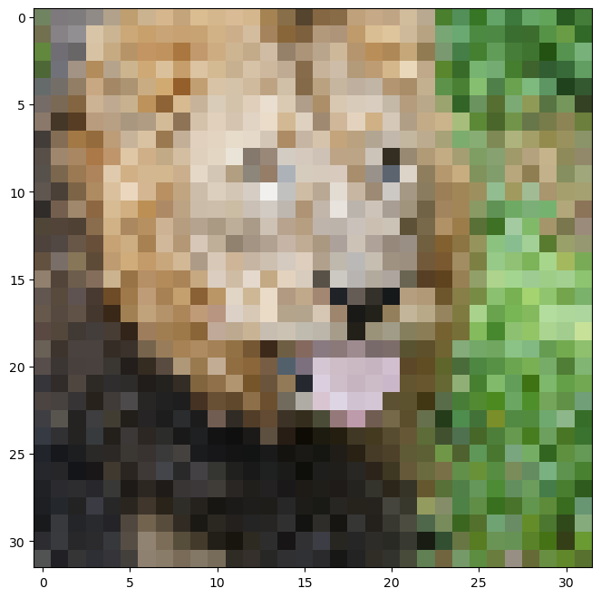

```python
size = 32
train_data, test_data = get_image(size)
```

Some suggested hyperparameter choices to help you start

- hidden layer count: 4
- hidden layer size: 256
- number of epochs: 1000
- learning rate: 1e-4

```python
# TODO: Set the hyperparameters
num_layers = 4
hidden_size = 256
hidden_sizes = [hidden_size] * (num_layers - 1)
epochs = 1000
learning_rate = 0.001
output_size = 3
B_dict = get_B_dict(size)

print('B_dict items:')
for k,v in B_dict.items():
    print('\t',k,np.array(v).shape)
```

```
B_dict items:
	 none ()
	 basic (2, 2)
	 gauss_1.0 (16, 2)
```

```python
# Apply the input feature mapping to the train and test data - already done for you
def get_input_features(B_dict, mapping):
  # mapping is the key to the B_dict, which has the value of B
  # B is then used with the function `input_mapping` to map x
  y_train = train_data[1].reshape(-1, output_size)
  y_test = test_data[1].reshape(-1, output_size)
  X_train = input_mapping(train_data[0].reshape(-1, 2), B_dict[mapping])
  X_test = input_mapping(test_data[0].reshape(-1, 2), B_dict[mapping])
  return X_train, y_train, X_test, y_test
```

### Plotting and video helper functions (you don't need to change anything here)

```python
def plot_training_curves(train_loss, train_psnr, test_psnr):
  # plot the training loss
  plt.subplot(2, 1, 1)
  plt.plot(train_loss)
  plt.title('MSE history')
  plt.xlabel('Iteration')
  plt.ylabel('MSE Loss')

  # plot the training and testing psnr
  plt.subplot(2, 1, 2)
  plt.plot(train_psnr, label='train')
  plt.plot(test_psnr, label='test')
  plt.title('PSNR history')
  plt.xlabel('Iteration')
  plt.ylabel('PSNR')
  plt.legend()

  plt.tight_layout()
  plt.show()

def plot_reconstruction(p, y):
  p_im = p.reshape(size,size,3)
  y_im = y.reshape(size,size,3)

  plt.figure(figsize=(12,6))

  # plot the reconstruction of the image
  plt.subplot(1,2,1), plt.imshow(p_im), plt.title("reconstruction")

  # plot the ground truth image
  plt.subplot(1,2,2), plt.imshow(y_im), plt.title("ground truth")

  print("Final Test MSE", mse(y, p))
  print("Final Test psnr",psnr(y, p))

def plot_reconstruction_progress(predicted_images, y, N=8):
  total = len(predicted_images)
  step = total // N
  plt.figure(figsize=(24, 4))

  # plot the progress of reconstructions
  for i, j in enumerate(range(0,total, step)):
      plt.subplot(1, N, i+1)
      plt.imshow(predicted_images[j].reshape(size,size,3))
      plt.axis("off")
      plt.title(f"iter {j}")

  # plot ground truth image
  plt.subplot(1, N+1, N+1)
  plt.imshow(y.reshape(size,size,3))
  plt.title('GT')
  plt.axis("off")
  plt.show()

def plot_feature_mapping_comparison(outputs, gt):
  # plot reconstruction images for each mapping
  plt.figure(figsize=(24, 4))
  N = len(outputs)
  for i, k in enumerate(outputs):
      plt.subplot(1, N+1, i+1)
      plt.imshow(outputs[k]['pred_imgs'][-1].reshape(size, size, -1))
      plt.title(k)
  plt.subplot(1, N+1, N+1)
  plt.imshow(gt)
  plt.title('GT')
  plt.show()

  # plot train/test error curves for each mapping
  iters = len(outputs[k]['train_psnrs'])
  plt.figure(figsize=(16, 6))
  plt.subplot(121)
  for i, k in enumerate(outputs):
      plt.plot(range(iters), outputs[k]['train_psnrs'], label=k)
  plt.title('Train error')
  plt.ylabel('PSNR')
  plt.xlabel('Training iter')
  plt.legend()
  plt.subplot(122)
  for i, k in enumerate(outputs):
      plt.plot(range(iters), outputs[k]['test_psnrs'], label=k)
  plt.title('Test error')
  plt.ylabel('PSNR')
  plt.xlabel('Training iter')
  plt.legend()
  plt.show()

# Save out video
def create_and_visualize_video(outputs, size=size, epochs=epochs, filename='training_convergence.mp4'):
  all_preds = np.concatenate([outputs[n]['pred_imgs'].reshape(epochs,size,size,3)[::25] for n in outputs], axis=-2)
  data8 = (255*np.clip(all_preds, 0, 1)).astype(np.uint8)
  f = os.path.join(filename)
  imageio.mimwrite(f, data8, fps=20)

  # Display video inline
  from IPython.display import HTML
  from base64 import b64encode
  mp4 = open(f, 'rb').read()
  data_url = "data:video/mp4;base64," + b64encode(mp4).decode()

  N = len(outputs)
  if N == 1:
    return HTML(f'''
    <video width=256 controls autoplay loop>
          <source src="{data_url}" type="video/mp4">
    </video>
    ''')
  else:
    return HTML(f'''
    <video width=1000 controls autoplay loop>
          <source src="{data_url}" type="video/mp4">
    </video>
    <table width="1000" cellspacing="0" cellpadding="0">
      <tr>{''.join(N*[f'<td width="{1000//len(outputs)}"></td>'])}</tr>
      <tr>{''.join(N*['<td style="text-align:center">{}</td>'])}</tr>
    </table>
    '''.format(*list(outputs.keys())))
```

### Experiment Runner (Fill in TODOs)

```python
def NN_experiment(X_train, y_train, X_test, y_test, input_size, num_layers,\
                  hidden_size, hidden_sizes, output_size, epochs,\
                  learning_rate, opt):

    # Initialize a new neural network model
    net = NeuralNetwork(input_size, hidden_sizes, output_size, num_layers, opt)

    # Variables to store performance for each epoch
    train_loss = np.zeros(epochs)
    train_psnr = np.zeros(epochs)
    test_psnr = np.zeros(epochs)
    predicted_images = np.zeros((epochs, y_test.shape[0], y_test.shape[1]))
    # For each epoch...
    # print(opt)

    for epoch in tqdm(range(epochs)):

      # Shuffle the dataset
      indices = np.arange(X_train.shape[0])
      np.random.shuffle(indices)

      X_train_shuffled = X_train[indices]
      y_train_shuffled = y_train[indices]

      # Training
      # Run the forward pass of the model to get a prediction and record the psnr
      prediction = net.forward(X_train_shuffled)
      train_psnr_value = psnr(y_train_shuffled, prediction)
      # Run the backward pass of the model to compute the loss, record the loss, and update the weights
      loss = net.backward(y_train_shuffled)
      net.update(learning_rate)

      p_test = net.forward(X_test)
      test_psnr_value = psnr(y_test, p_test)

      print(f"lr:{learning_rate} epoch:{epoch+1}, Loss:{loss:.7f}")

      train_psnr[epoch] = train_psnr_value
      train_loss[epoch] = loss
      test_psnr[epoch] = test_psnr_value
      predicted_images[epoch] = p_test

      # if (epoch + 1) % 20 == 0:
      #   learning_rate *= 0.95

    return net, train_psnr, test_psnr, train_loss, predicted_images
```

# Low Resolution Reconstruction

```
Opt:Adam, lr:0.0075
lr:0.0075 epoch:1, Loss:0.0532979
Opt:Adam, lr:0.0075
lr:0.0075 epoch:2, Loss:0.0903991
Opt:Adam, lr:0.0075
lr:0.0075 epoch:3, Loss:0.0722178
Opt:Adam, lr:0.0075
lr:0.0075 epoch:4, Loss:0.0441291
Opt:Adam, lr:0.0075
lr:0.0075 epoch:5, Loss:0.0383734
Opt:Adam, lr:0.0075
lr:0.0075 epoch:6, Loss:0.0380827
Opt:Adam, lr:0.0075
lr:0.0075 epoch:7, Loss:0.0363976
Opt:Adam, lr:0.0075
lr:0.0075 epoch:8, Loss:0.0340854
Opt:Adam, lr:0.0075
lr:0.0075 epoch:9, Loss:0.0326667
Opt:Adam, lr:0.0075
lr:0.0075 epoch:10, Loss:0.0330168
Opt:Adam, lr:0.0075
lr:0.0075 epoch:11, Loss:0.0328161
Opt:Adam, lr:0.0075
lr:0.0075 epoch:12, Loss:0.0321911
Opt:Adam, lr:0.0075
lr:0.0075 epoch:13, Loss:0.0316421
Opt:Adam, lr:0.0075
lr:0.0075 epoch:14, Loss:0.0312875
Opt:Adam, lr:0.0075
lr:0.0075 epoch:15, Loss:0.0310012
Opt:Adam, lr:0.0075
lr:0.0075 epoch:16, Loss:0.0305084
Opt:Adam, lr:0.0075
lr:0.0075 epoch:17, Loss:0.0299709
Opt:Adam, lr:0.0075
lr:0.0075 epoch:18, Loss:0.0295558
Opt:Adam, lr:0.0075
lr:0.0075 epoch:19, Loss:0.0290438
Opt:Adam, lr:0.0075
lr:0.0075 epoch:20, Loss:0.0283477
```

[output cut: 1945 more lines]

```
lr:0.0075 epoch:993, Loss:0.0017853
Opt:Adam, lr:0.0075
lr:0.0075 epoch:994, Loss:0.0018049
Opt:Adam, lr:0.0075
lr:0.0075 epoch:995, Loss:0.0018009
Opt:Adam, lr:0.0075
lr:0.0075 epoch:996, Loss:0.0017491
Opt:Adam, lr:0.0075
lr:0.0075 epoch:997, Loss:0.0017514
Opt:Adam, lr:0.0075
lr:0.0075 epoch:998, Loss:0.0017021
Opt:Adam, lr:0.0075
lr:0.0075 epoch:999, Loss:0.0017355
Opt:Adam, lr:0.0075
lr:0.0075 epoch:1000, Loss:0.0016861
```

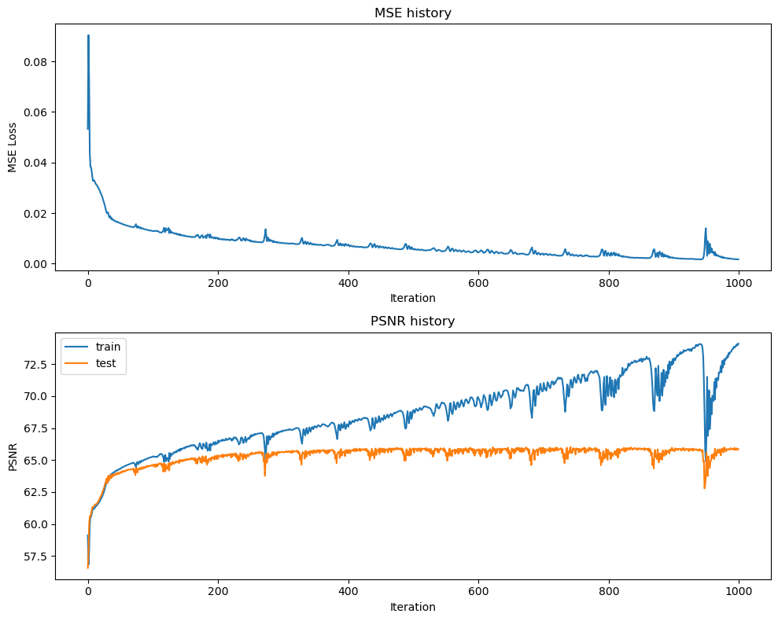

```
Final Test MSE 0.01693566884323399
Final Test psnr 65.8427800788314
```

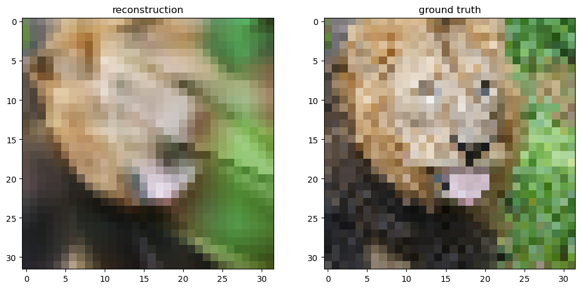

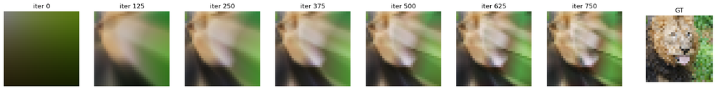

```python
# get input features
# TODO implement this by using the get_B_dict() and get_input_features() helper functions
B_dict = get_B_dict(size)
X_train, y_train, X_test, y_test = get_input_features(B_dict, mapping='none')
input_size = X_train.shape[1]
# run NN experiment on input features
# TODO implement by using the NN_experiment() helper function
opt = 'SGD'

learning_rate = 0.0075

net, train_psnr, test_psnr, train_loss, predicted_images = NN_experiment(
    X_train, y_train, X_test, y_test, input_size, num_layers,
    hidden_size, hidden_sizes, output_size, epochs, learning_rate, opt)


# plot results of experiment
plot_training_curves(train_loss, train_psnr, test_psnr)
plot_reconstruction(net.forward(X_test), y_test)
plot_reconstruction_progress(predicted_images, y_test)
```

```
Opt:Adam, lr:0.0075
lr:0.0075 epoch:1, Loss:0.0562683
Opt:Adam, lr:0.0075
lr:0.0075 epoch:2, Loss:0.0868021
Opt:Adam, lr:0.0075
lr:0.0075 epoch:3, Loss:0.1077888
Opt:Adam, lr:0.0075
lr:0.0075 epoch:4, Loss:0.0497494
Opt:Adam, lr:0.0075
lr:0.0075 epoch:5, Loss:0.0347378
Opt:Adam, lr:0.0075
lr:0.0075 epoch:6, Loss:0.0315374
Opt:Adam, lr:0.0075
lr:0.0075 epoch:7, Loss:0.0292265
Opt:Adam, lr:0.0075
lr:0.0075 epoch:8, Loss:0.0264724
Opt:Adam, lr:0.0075
lr:0.0075 epoch:9, Loss:0.0237940
Opt:Adam, lr:0.0075
lr:0.0075 epoch:10, Loss:0.0215123
Opt:Adam, lr:0.0075
lr:0.0075 epoch:11, Loss:0.0197432
Opt:Adam, lr:0.0075
lr:0.0075 epoch:12, Loss:0.0185549
Opt:Adam, lr:0.0075
lr:0.0075 epoch:13, Loss:0.0180467
Opt:Adam, lr:0.0075
lr:0.0075 epoch:14, Loss:0.0179835
Opt:Adam, lr:0.0075
lr:0.0075 epoch:15, Loss:0.0176226
Opt:Adam, lr:0.0075
lr:0.0075 epoch:16, Loss:0.0168463
Opt:Adam, lr:0.0075
lr:0.0075 epoch:17, Loss:0.0160548
Opt:Adam, lr:0.0075
lr:0.0075 epoch:18, Loss:0.0155145
Opt:Adam, lr:0.0075
lr:0.0075 epoch:19, Loss:0.0151759
Opt:Adam, lr:0.0075
lr:0.0075 epoch:20, Loss:0.0149799
```

[output cut: 1945 more lines]

```
lr:0.0075 epoch:993, Loss:0.0000925
Opt:Adam, lr:0.0075
lr:0.0075 epoch:994, Loss:0.0001204
Opt:Adam, lr:0.0075
lr:0.0075 epoch:995, Loss:0.0000962
Opt:Adam, lr:0.0075
lr:0.0075 epoch:996, Loss:0.0000520
Opt:Adam, lr:0.0075
lr:0.0075 epoch:997, Loss:0.0000149
Opt:Adam, lr:0.0075
lr:0.0075 epoch:998, Loss:0.0000094
Opt:Adam, lr:0.0075
lr:0.0075 epoch:999, Loss:0.0000306
Opt:Adam, lr:0.0075
lr:0.0075 epoch:1000, Loss:0.0000531
```

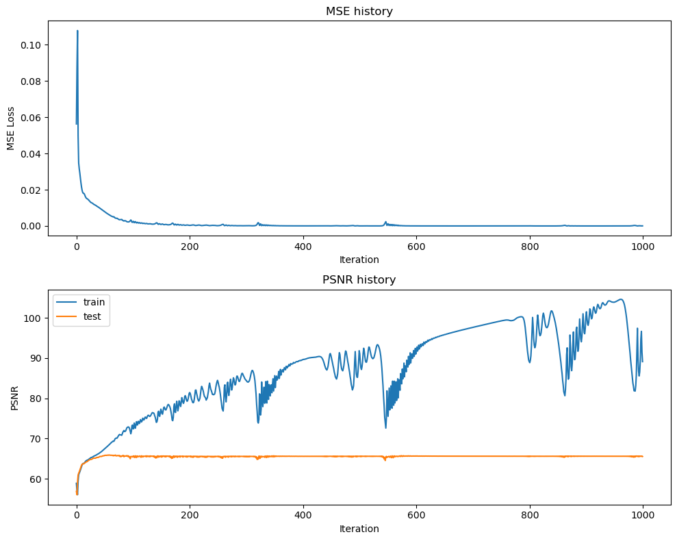

```
Final Test MSE 0.018174871655154384
Final Test psnr 65.53609008167923
```

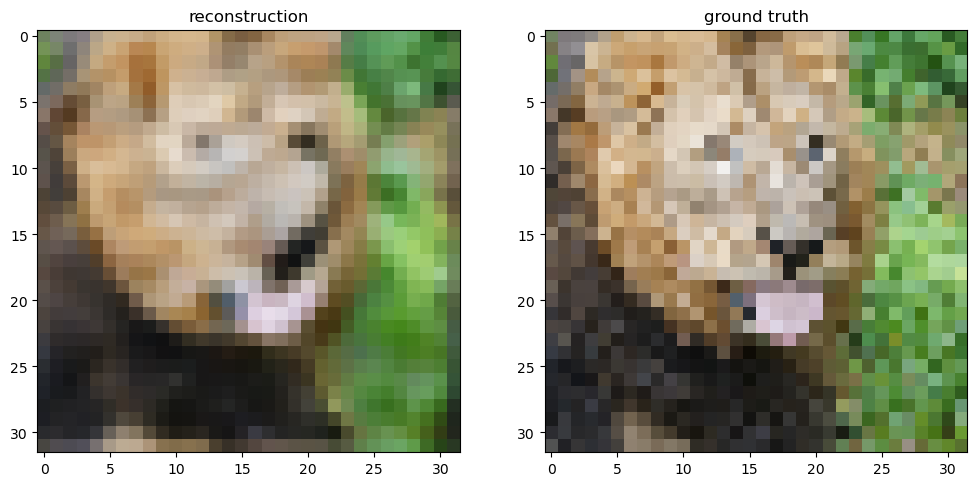

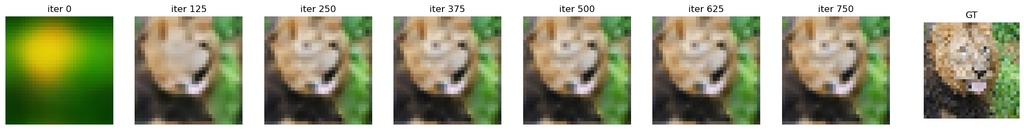

```python
# get input features
# TODO implement this by using the get_B_dict() and get_input_features() helper functions
B_dict = get_B_dict(size)
X_train, y_train, X_test, y_test = get_input_features(B_dict, mapping='basic')
input_size = X_train.shape[1]
# run NN experiment on input features
# TODO implement by using the NN_experiment() helper function
opt = 'SGD'

learning_rate = 0.0075

net, train_psnr, test_psnr, train_loss, predicted_images = NN_experiment(
    X_train, y_train, X_test, y_test, input_size, num_layers,
    hidden_size, hidden_sizes, output_size, epochs, learning_rate, opt)


# plot results of experiment
plot_training_curves(train_loss, train_psnr, test_psnr)
plot_reconstruction(net.forward(X_test), y_test)
plot_reconstruction_progress(predicted_images, y_test)
```

```
Opt:Adam, lr:0.0075
lr:0.0075 epoch:1, Loss:0.0615902
Opt:Adam, lr:0.0075
lr:0.0075 epoch:2, Loss:0.0755633
Opt:Adam, lr:0.0075
lr:0.0075 epoch:3, Loss:0.1051487
Opt:Adam, lr:0.0075
lr:0.0075 epoch:4, Loss:0.0353146
Opt:Adam, lr:0.0075
lr:0.0075 epoch:5, Loss:0.0289869
Opt:Adam, lr:0.0075
lr:0.0075 epoch:6, Loss:0.0267659
Opt:Adam, lr:0.0075
lr:0.0075 epoch:7, Loss:0.0227690
Opt:Adam, lr:0.0075
lr:0.0075 epoch:8, Loss:0.0204537
Opt:Adam, lr:0.0075
lr:0.0075 epoch:9, Loss:0.0187442
Opt:Adam, lr:0.0075
lr:0.0075 epoch:10, Loss:0.0170359
Opt:Adam, lr:0.0075
lr:0.0075 epoch:11, Loss:0.0157409
Opt:Adam, lr:0.0075
lr:0.0075 epoch:12, Loss:0.0152060
Opt:Adam, lr:0.0075
lr:0.0075 epoch:13, Loss:0.0152243
Opt:Adam, lr:0.0075
lr:0.0075 epoch:14, Loss:0.0150288
Opt:Adam, lr:0.0075
lr:0.0075 epoch:15, Loss:0.0143156
Opt:Adam, lr:0.0075
lr:0.0075 epoch:16, Loss:0.0133418
Opt:Adam, lr:0.0075
lr:0.0075 epoch:17, Loss:0.0124712
Opt:Adam, lr:0.0075
lr:0.0075 epoch:18, Loss:0.0118909
Opt:Adam, lr:0.0075
lr:0.0075 epoch:19, Loss:0.0115679
Opt:Adam, lr:0.0075
lr:0.0075 epoch:20, Loss:0.0113503
```

[output cut: 1945 more lines]

```
lr:0.0075 epoch:993, Loss:0.0000001
Opt:Adam, lr:0.0075
lr:0.0075 epoch:994, Loss:0.0000001
Opt:Adam, lr:0.0075
lr:0.0075 epoch:995, Loss:0.0000001
Opt:Adam, lr:0.0075
lr:0.0075 epoch:996, Loss:0.0000001
Opt:Adam, lr:0.0075
lr:0.0075 epoch:997, Loss:0.0000001
Opt:Adam, lr:0.0075
lr:0.0075 epoch:998, Loss:0.0000001
Opt:Adam, lr:0.0075
lr:0.0075 epoch:999, Loss:0.0000001
Opt:Adam, lr:0.0075
lr:0.0075 epoch:1000, Loss:0.0000001
```

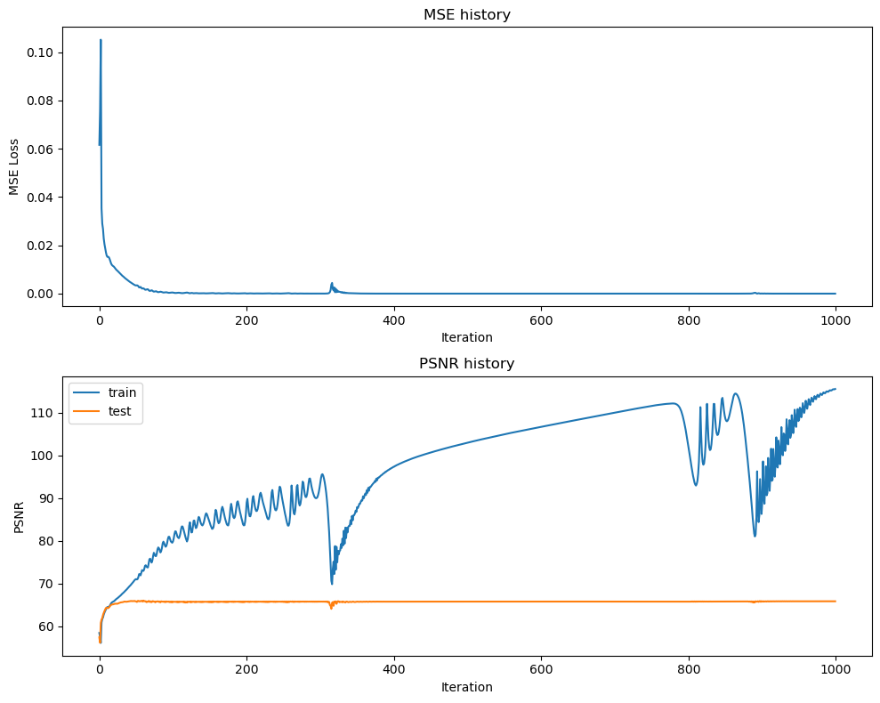

```
Final Test MSE 0.01673580030987514
Final Test psnr 65.8943387561409
```

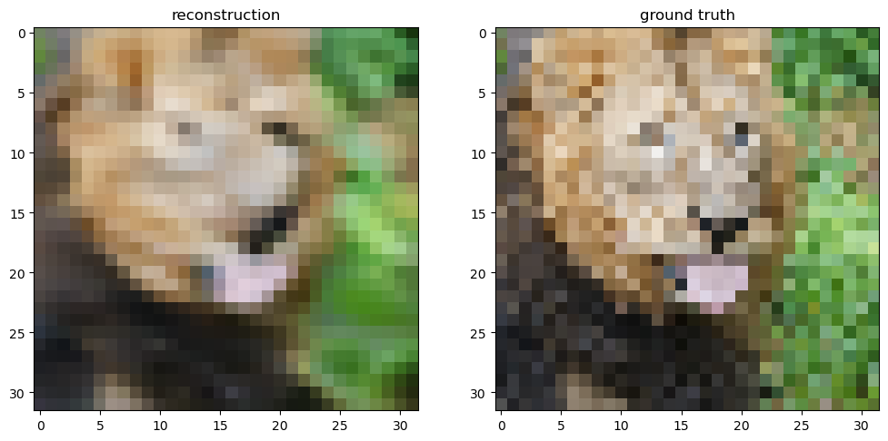

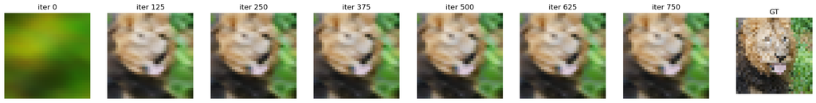

```python
# get input features
# TODO implement this by using the get_B_dict() and get_input_features() helper functions
B_dict = get_B_dict(size)
X_train, y_train, X_test, y_test = get_input_features(B_dict, mapping='gauss_1.0')
input_size = X_train.shape[1]
# run NN experiment on input features
# TODO implement by using the NN_experiment() helper function
opt = 'SGD'

learning_rate = 0.0075

net, train_psnr, test_psnr, train_loss, predicted_images = NN_experiment(
    X_train, y_train, X_test, y_test, input_size, num_layers,
    hidden_size, hidden_sizes, output_size, epochs, learning_rate, opt)


# plot results of experiment
plot_training_curves(train_loss, train_psnr, test_psnr)
plot_reconstruction(net.forward(X_test), y_test)
plot_reconstruction_progress(predicted_images, y_test)
```

#### Low Resolution Reconstruction - Adam - None Mapping

```
Opt:Adam, lr:0.005
lr:0.005 epoch:1, Loss:0.0631540
Opt:Adam, lr:0.005
lr:0.005 epoch:2, Loss:0.0506966
Opt:Adam, lr:0.005
lr:0.005 epoch:3, Loss:0.0462845
Opt:Adam, lr:0.005
lr:0.005 epoch:4, Loss:0.0359931
Opt:Adam, lr:0.005
lr:0.005 epoch:5, Loss:0.0372927
Opt:Adam, lr:0.005
lr:0.005 epoch:6, Loss:0.0343950
Opt:Adam, lr:0.005
lr:0.005 epoch:7, Loss:0.0334617
Opt:Adam, lr:0.005
lr:0.005 epoch:8, Loss:0.0340622
Opt:Adam, lr:0.005
lr:0.005 epoch:9, Loss:0.0330964
Opt:Adam, lr:0.005
lr:0.005 epoch:10, Loss:0.0322158
Opt:Adam, lr:0.005
lr:0.005 epoch:11, Loss:0.0320684
Opt:Adam, lr:0.005
lr:0.005 epoch:12, Loss:0.0317879
Opt:Adam, lr:0.005
lr:0.005 epoch:13, Loss:0.0310481
Opt:Adam, lr:0.005
lr:0.005 epoch:14, Loss:0.0303479
Opt:Adam, lr:0.005
lr:0.005 epoch:15, Loss:0.0300076
Opt:Adam, lr:0.005
lr:0.005 epoch:16, Loss:0.0296049
Opt:Adam, lr:0.005
lr:0.005 epoch:17, Loss:0.0290804
Opt:Adam, lr:0.005
lr:0.005 epoch:18, Loss:0.0282532
Opt:Adam, lr:0.005
lr:0.005 epoch:19, Loss:0.0275767
Opt:Adam, lr:0.005
lr:0.005 epoch:20, Loss:0.0269492
```

[output cut: 1945 more lines]

```
lr:0.005 epoch:993, Loss:0.0043298
Opt:Adam, lr:0.005
lr:0.005 epoch:994, Loss:0.0035514
Opt:Adam, lr:0.005
lr:0.005 epoch:995, Loss:0.0028997
Opt:Adam, lr:0.005
lr:0.005 epoch:996, Loss:0.0030558
Opt:Adam, lr:0.005
lr:0.005 epoch:997, Loss:0.0033318
Opt:Adam, lr:0.005
lr:0.005 epoch:998, Loss:0.0036073
Opt:Adam, lr:0.005
lr:0.005 epoch:999, Loss:0.0034841
Opt:Adam, lr:0.005
lr:0.005 epoch:1000, Loss:0.0028530
```

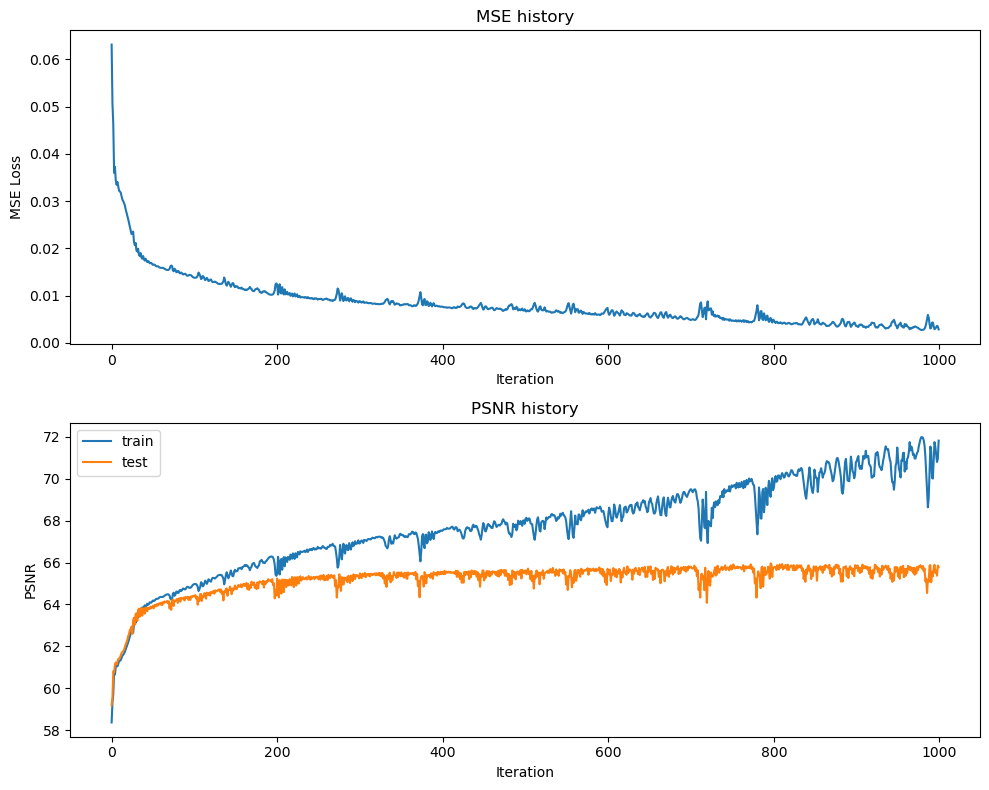

```
Final Test MSE 0.017160759770578966
Final Test psnr 65.7854384909966
```

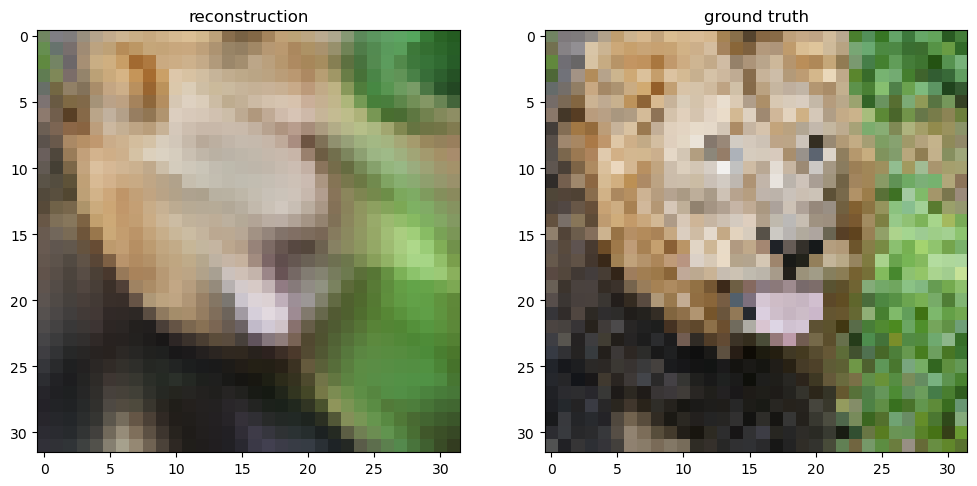

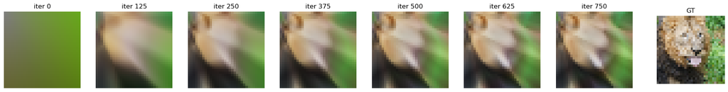

```python
# get input features
# TODO implement this by using the get_B_dict() and get_input_features() helper functions
B_dict = get_B_dict(size)
X_train, y_train, X_test, y_test = get_input_features(B_dict, mapping='none')
input_size = X_train.shape[1]
# run NN experiment on input features
# TODO implement by using the NN_experiment() helper function


opt = 'Adam'
learning_rate = 0.005

net, train_psnr, test_psnr, train_loss, predicted_images = NN_experiment(
    X_train, y_train, X_test, y_test, input_size, num_layers,
    hidden_size, hidden_sizes, output_size, epochs, learning_rate, opt)
# plot results of experiment
plot_training_curves(train_loss, train_psnr, test_psnr)
plot_reconstruction(net.forward(X_test), y_test)
plot_reconstruction_progress(predicted_images, y_test)
```

```
Opt:Adam, lr:0.005
lr:0.005 epoch:1, Loss:0.0643629
Opt:Adam, lr:0.005
lr:0.005 epoch:2, Loss:0.0536626
Opt:Adam, lr:0.005
lr:0.005 epoch:3, Loss:0.0392993
Opt:Adam, lr:0.005
lr:0.005 epoch:4, Loss:0.0246044
Opt:Adam, lr:0.005
lr:0.005 epoch:5, Loss:0.0273498
Opt:Adam, lr:0.005
lr:0.005 epoch:6, Loss:0.0243333
Opt:Adam, lr:0.005
lr:0.005 epoch:7, Loss:0.0206006
Opt:Adam, lr:0.005
lr:0.005 epoch:8, Loss:0.0202470
Opt:Adam, lr:0.005
lr:0.005 epoch:9, Loss:0.0198701
Opt:Adam, lr:0.005
lr:0.005 epoch:10, Loss:0.0183185
Opt:Adam, lr:0.005
lr:0.005 epoch:11, Loss:0.0171404
Opt:Adam, lr:0.005
lr:0.005 epoch:12, Loss:0.0171389
Opt:Adam, lr:0.005
lr:0.005 epoch:13, Loss:0.0170449
Opt:Adam, lr:0.005
lr:0.005 epoch:14, Loss:0.0161330
Opt:Adam, lr:0.005
lr:0.005 epoch:15, Loss:0.0152451
Opt:Adam, lr:0.005
lr:0.005 epoch:16, Loss:0.0149558
Opt:Adam, lr:0.005
lr:0.005 epoch:17, Loss:0.0147668
Opt:Adam, lr:0.005
lr:0.005 epoch:18, Loss:0.0143412
Opt:Adam, lr:0.005
lr:0.005 epoch:19, Loss:0.0140096
Opt:Adam, lr:0.005
lr:0.005 epoch:20, Loss:0.0138936
```

[output cut: 1945 more lines]

```
lr:0.005 epoch:993, Loss:0.0000010
Opt:Adam, lr:0.005
lr:0.005 epoch:994, Loss:0.0000010
Opt:Adam, lr:0.005
lr:0.005 epoch:995, Loss:0.0000010
Opt:Adam, lr:0.005
lr:0.005 epoch:996, Loss:0.0000010
Opt:Adam, lr:0.005
lr:0.005 epoch:997, Loss:0.0000010
Opt:Adam, lr:0.005
lr:0.005 epoch:998, Loss:0.0000010
Opt:Adam, lr:0.005
lr:0.005 epoch:999, Loss:0.0000010
Opt:Adam, lr:0.005
lr:0.005 epoch:1000, Loss:0.0000010
```

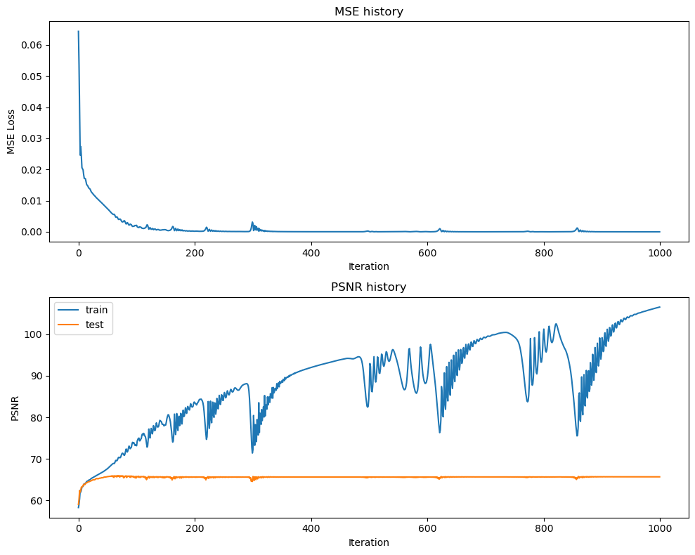

```
Final Test MSE 0.017584216599557702
Final Test psnr 65.67957336185826
```

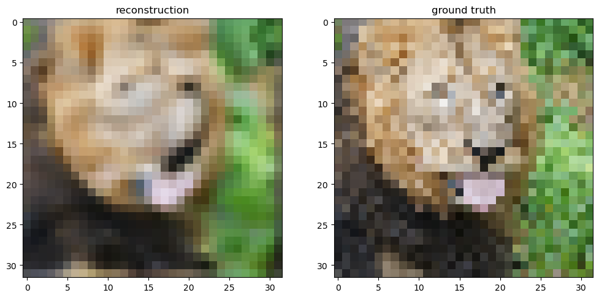

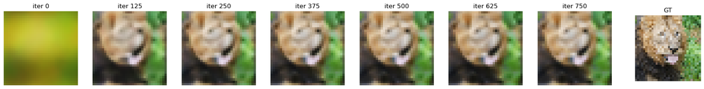

```python
# get input features
# TODO implement this by using the get_B_dict() and get_input_features() helper functions
B_dict = get_B_dict(size)
X_train, y_train, X_test, y_test = get_input_features(B_dict, mapping='basic')
input_size = X_train.shape[1]
# run NN experiment on input features
# TODO implement by using the NN_experiment() helper function


opt = 'Adam'
learning_rate = 0.005

net, train_psnr, test_psnr, train_loss, predicted_images = NN_experiment(
    X_train, y_train, X_test, y_test, input_size, num_layers,
    hidden_size, hidden_sizes, output_size, epochs, learning_rate, opt)
# plot results of experiment
plot_training_curves(train_loss, train_psnr, test_psnr)
plot_reconstruction(net.forward(X_test), y_test)
plot_reconstruction_progress(predicted_images, y_test)
```

```
Opt:Adam, lr:0.005
lr:0.005 epoch:1, Loss:0.0557682
Opt:Adam, lr:0.005
lr:0.005 epoch:2, Loss:0.0526565
Opt:Adam, lr:0.005
lr:0.005 epoch:3, Loss:0.0415356
Opt:Adam, lr:0.005
lr:0.005 epoch:4, Loss:0.0188838
Opt:Adam, lr:0.005
lr:0.005 epoch:5, Loss:0.0183639
Opt:Adam, lr:0.005
lr:0.005 epoch:6, Loss:0.0195562
Opt:Adam, lr:0.005
lr:0.005 epoch:7, Loss:0.0180848
Opt:Adam, lr:0.005
lr:0.005 epoch:8, Loss:0.0161215
Opt:Adam, lr:0.005
lr:0.005 epoch:9, Loss:0.0143870
Opt:Adam, lr:0.005
lr:0.005 epoch:10, Loss:0.0132235
Opt:Adam, lr:0.005
lr:0.005 epoch:11, Loss:0.0126503
Opt:Adam, lr:0.005
lr:0.005 epoch:12, Loss:0.0122441
Opt:Adam, lr:0.005
lr:0.005 epoch:13, Loss:0.0117958
Opt:Adam, lr:0.005
lr:0.005 epoch:14, Loss:0.0114766
Opt:Adam, lr:0.005
lr:0.005 epoch:15, Loss:0.0111327
Opt:Adam, lr:0.005
lr:0.005 epoch:16, Loss:0.0105846
Opt:Adam, lr:0.005
lr:0.005 epoch:17, Loss:0.0100262
Opt:Adam, lr:0.005
lr:0.005 epoch:18, Loss:0.0096119
Opt:Adam, lr:0.005
lr:0.005 epoch:19, Loss:0.0091471
Opt:Adam, lr:0.005
lr:0.005 epoch:20, Loss:0.0086198
```

[output cut: 1945 more lines]

```
lr:0.005 epoch:993, Loss:0.0000539
Opt:Adam, lr:0.005
lr:0.005 epoch:994, Loss:0.0001779
Opt:Adam, lr:0.005
lr:0.005 epoch:995, Loss:0.0000577
Opt:Adam, lr:0.005
lr:0.005 epoch:996, Loss:0.0001291
Opt:Adam, lr:0.005
lr:0.005 epoch:997, Loss:0.0000622
Opt:Adam, lr:0.005
lr:0.005 epoch:998, Loss:0.0000893
Opt:Adam, lr:0.005
lr:0.005 epoch:999, Loss:0.0000645
Opt:Adam, lr:0.005
lr:0.005 epoch:1000, Loss:0.0000568
```

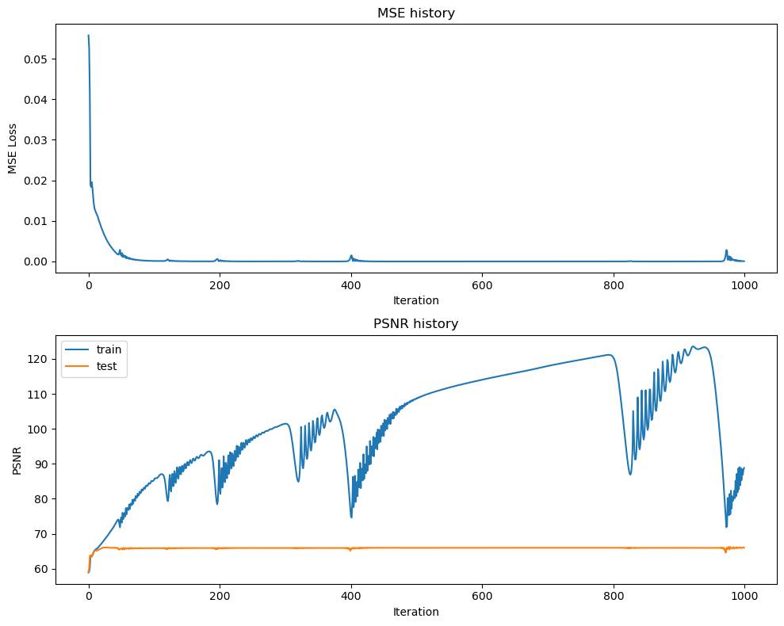

```
Final Test MSE 0.016382078784921966
Final Test psnr 65.98711350651199
```

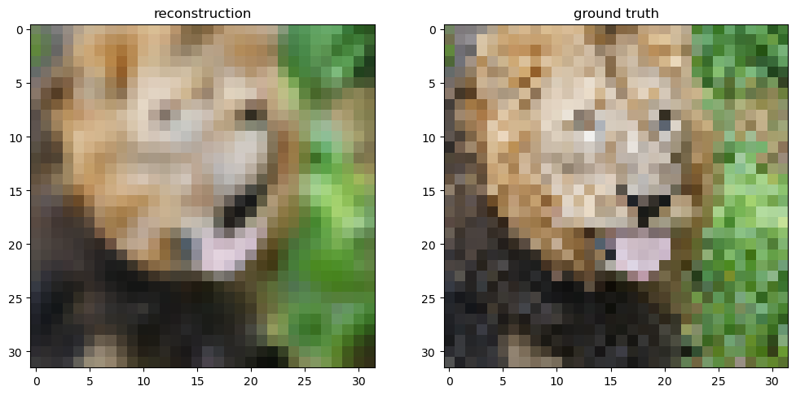

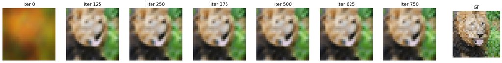

```python
# get input features
# TODO implement this by using the get_B_dict() and get_input_features() helper functions
B_dict = get_B_dict(size)
X_train, y_train, X_test, y_test = get_input_features(B_dict, mapping='gauss_1.0')
input_size = X_train.shape[1]
# run NN experiment on input features
# TODO implement by using the NN_experiment() helper function


opt = 'Adam'
learning_rate = 0.005

net, train_psnr, test_psnr, train_loss, predicted_images = NN_experiment(
    X_train, y_train, X_test, y_test, input_size, num_layers,
    hidden_size, hidden_sizes, output_size, epochs, learning_rate, opt)
# plot results of experiment
plot_training_curves(train_loss, train_psnr, test_psnr)
plot_reconstruction(net.forward(X_test), y_test)
plot_reconstruction_progress(predicted_images, y_test)
```

#### Low Resolution Reconstruction - Optimizer of your Choice - Various Input Mapping Stategies

```python
def train_wrapper(mapping, size, opt):
  # TODO implement
  # makes it easy to run all your mapping experiments in a for loop
  # this will similar to what you did previously in the last two sections
  B_dict = get_B_dict(size)
  X_train, y_train, X_test, y_test = get_input_features(B_dict, mapping=mapping)
  input_size = X_train.shape[1]
# run NN experiment on input features
# TODO implement by using the NN_experiment() helper function
  opt = 'Adam'
  # learning_rate = 0.005

  # learning_rate = 0.01
  # epochs = 1000
  # num_layers = 8
  # hidden_size = 512
  # hidden_sizes = [hidden_size] * (num_layers - 1)
  # output_size = 3


  net, train_psnr, test_psnr, train_loss, predicted_images = NN_experiment(
    X_train, y_train, X_test, y_test, input_size, num_layers,
    hidden_size, hidden_sizes, output_size, epochs, learning_rate, opt)

  # net, train_psnr, test_psnr, train_loss, predicted_images = NN_experiment(
  #                       X_train, y_train, X_test, y_test, input_size, num_layers,\
  #                       hidden_size, hidden_sizes, output_size, epochs=1000,\
  #                       learning_rate=0.1, opt="Adam")

  return {
      'net': net,
      'train_psnrs': train_psnr,
      'test_psnrs': test_psnr,
      'train_loss': train_loss,
      'pred_imgs': predicted_images
  }
```

```python
outputs = {}
# opt = "Adam"
for k in tqdm(B_dict):
  print("training", k)
  outputs[k] = train_wrapper(k, size, opt)
```

```
training none
```

```
Opt:Adam, lr:0.005
lr:0.005 epoch:1, Loss:0.0560422
Opt:Adam, lr:0.005
lr:0.005 epoch:2, Loss:0.0563554
Opt:Adam, lr:0.005
lr:0.005 epoch:3, Loss:0.0398679
Opt:Adam, lr:0.005
lr:0.005 epoch:4, Loss:0.0403296
Opt:Adam, lr:0.005
lr:0.005 epoch:5, Loss:0.0347037
Opt:Adam, lr:0.005
lr:0.005 epoch:6, Loss:0.0341601
Opt:Adam, lr:0.005
lr:0.005 epoch:7, Loss:0.0344335
Opt:Adam, lr:0.005
lr:0.005 epoch:8, Loss:0.0330636
Opt:Adam, lr:0.005
lr:0.005 epoch:9, Loss:0.0332285
Opt:Adam, lr:0.005
lr:0.005 epoch:10, Loss:0.0327490
Opt:Adam, lr:0.005
lr:0.005 epoch:11, Loss:0.0317798
Opt:Adam, lr:0.005
lr:0.005 epoch:12, Loss:0.0313799
Opt:Adam, lr:0.005
lr:0.005 epoch:13, Loss:0.0313331
Opt:Adam, lr:0.005
lr:0.005 epoch:14, Loss:0.0308276
Opt:Adam, lr:0.005
lr:0.005 epoch:15, Loss:0.0301969
Opt:Adam, lr:0.005
lr:0.005 epoch:16, Loss:0.0297658
Opt:Adam, lr:0.005
lr:0.005 epoch:17, Loss:0.0292781
Opt:Adam, lr:0.005
lr:0.005 epoch:18, Loss:0.0286804
Opt:Adam, lr:0.005
lr:0.005 epoch:19, Loss:0.0280227
Opt:Adam, lr:0.005
lr:0.005 epoch:20, Loss:0.0274941
```

[output cut: 1946 more lines]

```
Opt:Adam, lr:0.005
lr:0.005 epoch:994, Loss:0.0024019
Opt:Adam, lr:0.005
lr:0.005 epoch:995, Loss:0.0021556
Opt:Adam, lr:0.005
lr:0.005 epoch:996, Loss:0.0019605
Opt:Adam, lr:0.005
lr:0.005 epoch:997, Loss:0.0019942
Opt:Adam, lr:0.005
lr:0.005 epoch:998, Loss:0.0020085
Opt:Adam, lr:0.005
lr:0.005 epoch:999, Loss:0.0019748
Opt:Adam, lr:0.005
lr:0.005 epoch:1000, Loss:0.0019002
training basic
```

```
Opt:Adam, lr:0.005
lr:0.005 epoch:1, Loss:0.0606255
Opt:Adam, lr:0.005
lr:0.005 epoch:2, Loss:0.0599591
Opt:Adam, lr:0.005
lr:0.005 epoch:3, Loss:0.0446208
Opt:Adam, lr:0.005
lr:0.005 epoch:4, Loss:0.0247089
Opt:Adam, lr:0.005
lr:0.005 epoch:5, Loss:0.0284801
Opt:Adam, lr:0.005
lr:0.005 epoch:6, Loss:0.0238745
Opt:Adam, lr:0.005
lr:0.005 epoch:7, Loss:0.0200977
Opt:Adam, lr:0.005
lr:0.005 epoch:8, Loss:0.0191347
Opt:Adam, lr:0.005
lr:0.005 epoch:9, Loss:0.0189474
Opt:Adam, lr:0.005
lr:0.005 epoch:10, Loss:0.0186929
Opt:Adam, lr:0.005
lr:0.005 epoch:11, Loss:0.0176414
Opt:Adam, lr:0.005
lr:0.005 epoch:12, Loss:0.0164501
Opt:Adam, lr:0.005
lr:0.005 epoch:13, Loss:0.0156821
Opt:Adam, lr:0.005
lr:0.005 epoch:14, Loss:0.0150892
Opt:Adam, lr:0.005
lr:0.005 epoch:15, Loss:0.0145743
Opt:Adam, lr:0.005
lr:0.005 epoch:16, Loss:0.0142241
Opt:Adam, lr:0.005
lr:0.005 epoch:17, Loss:0.0140636
Opt:Adam, lr:0.005
lr:0.005 epoch:18, Loss:0.0139255
Opt:Adam, lr:0.005
lr:0.005 epoch:19, Loss:0.0136072
Opt:Adam, lr:0.005
lr:0.005 epoch:20, Loss:0.0131224
```

[output cut: 1946 more lines]

```
Opt:Adam, lr:0.005
lr:0.005 epoch:994, Loss:0.0000007
Opt:Adam, lr:0.005
lr:0.005 epoch:995, Loss:0.0000007
Opt:Adam, lr:0.005
lr:0.005 epoch:996, Loss:0.0000007
Opt:Adam, lr:0.005
lr:0.005 epoch:997, Loss:0.0000007
Opt:Adam, lr:0.005
lr:0.005 epoch:998, Loss:0.0000007
Opt:Adam, lr:0.005
lr:0.005 epoch:999, Loss:0.0000007
Opt:Adam, lr:0.005
lr:0.005 epoch:1000, Loss:0.0000006
training gauss_1.0
```

```
Opt:Adam, lr:0.005
lr:0.005 epoch:1, Loss:0.0663315
Opt:Adam, lr:0.005
lr:0.005 epoch:2, Loss:0.0679175
Opt:Adam, lr:0.005
lr:0.005 epoch:3, Loss:0.0348247
Opt:Adam, lr:0.005
lr:0.005 epoch:4, Loss:0.0220600
Opt:Adam, lr:0.005
lr:0.005 epoch:5, Loss:0.0201650
Opt:Adam, lr:0.005
lr:0.005 epoch:6, Loss:0.0216111
Opt:Adam, lr:0.005
lr:0.005 epoch:7, Loss:0.0189155
Opt:Adam, lr:0.005
lr:0.005 epoch:8, Loss:0.0168265
Opt:Adam, lr:0.005
lr:0.005 epoch:9, Loss:0.0161859
Opt:Adam, lr:0.005
lr:0.005 epoch:10, Loss:0.0152061
Opt:Adam, lr:0.005
lr:0.005 epoch:11, Loss:0.0142344
Opt:Adam, lr:0.005
lr:0.005 epoch:12, Loss:0.0140741
Opt:Adam, lr:0.005
lr:0.005 epoch:13, Loss:0.0138393
Opt:Adam, lr:0.005
lr:0.005 epoch:14, Loss:0.0128592
Opt:Adam, lr:0.005
lr:0.005 epoch:15, Loss:0.0120066
Opt:Adam, lr:0.005
lr:0.005 epoch:16, Loss:0.0117397
Opt:Adam, lr:0.005
lr:0.005 epoch:17, Loss:0.0115351
Opt:Adam, lr:0.005
lr:0.005 epoch:18, Loss:0.0110531
Opt:Adam, lr:0.005
lr:0.005 epoch:19, Loss:0.0105098
Opt:Adam, lr:0.005
lr:0.005 epoch:20, Loss:0.0101977
```

[output cut: 1945 more lines]

```
lr:0.005 epoch:993, Loss:0.0000002
Opt:Adam, lr:0.005
lr:0.005 epoch:994, Loss:0.0000002
Opt:Adam, lr:0.005
lr:0.005 epoch:995, Loss:0.0000002
Opt:Adam, lr:0.005
lr:0.005 epoch:996, Loss:0.0000002
Opt:Adam, lr:0.005
lr:0.005 epoch:997, Loss:0.0000002
Opt:Adam, lr:0.005
lr:0.005 epoch:998, Loss:0.0000002
Opt:Adam, lr:0.005
lr:0.005 epoch:999, Loss:0.0000002
Opt:Adam, lr:0.005
lr:0.005 epoch:1000, Loss:0.0000002
```

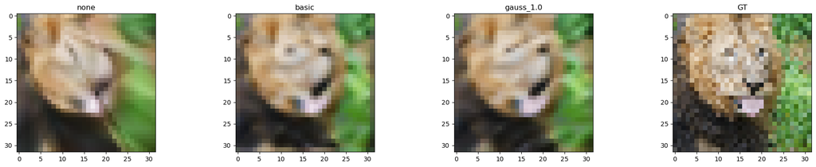

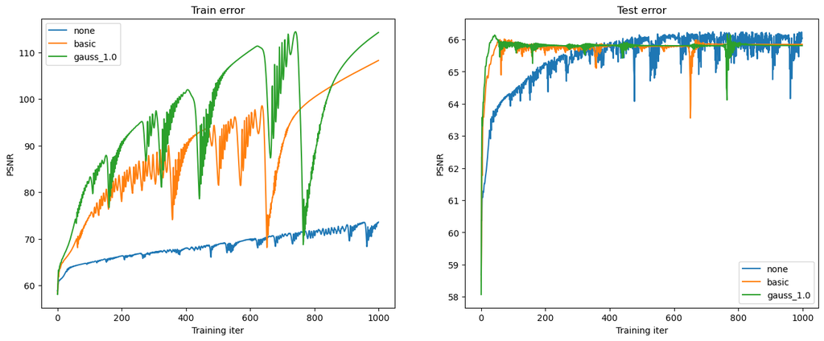

```python
# if you did everything correctly so far, this should output a nice figure you can use in your report
plot_feature_mapping_comparison(outputs, y_test.reshape(size,size,3))
```

# High Resolution Reconstruction

#### High Resolution Reconstruction - Optimizer of your Choice - Various Input Mapping Stategies

Repeat the previous experiment, but at the higher resolution. The reason why we have you first experiment with the lower resolution since it is faster to train and debug. Additionally, you will see how the mapping strategies perform better or worse at the two different input resolutions.

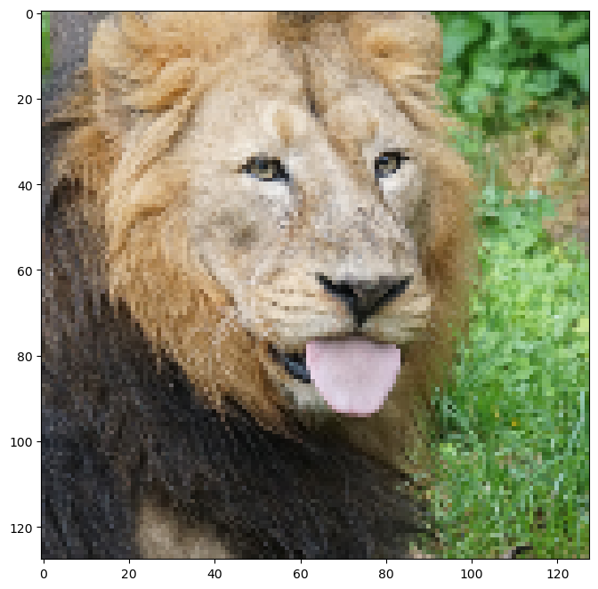

```python
size = 128
train_data, test_data = get_image(size)
```

```python
outputs = {}
for k in tqdm(B_dict):
  print("training", k)
  outputs[k] = train_wrapper(k, size, opt)
```

```
training none
```

```
Opt:Adam, lr:0.0025
lr:0.0025 epoch:1, Loss:0.0554131
Opt:Adam, lr:0.0025
lr:0.0025 epoch:2, Loss:0.0503938
Opt:Adam, lr:0.0025
lr:0.0025 epoch:3, Loss:0.0452148
Opt:Adam, lr:0.0025
lr:0.0025 epoch:4, Loss:0.0386298
Opt:Adam, lr:0.0025
lr:0.0025 epoch:5, Loss:0.0348525
Opt:Adam, lr:0.0025
lr:0.0025 epoch:6, Loss:0.0351835
Opt:Adam, lr:0.0025
lr:0.0025 epoch:7, Loss:0.0352399
Opt:Adam, lr:0.0025
lr:0.0025 epoch:8, Loss:0.0340244
Opt:Adam, lr:0.0025
lr:0.0025 epoch:9, Loss:0.0329812
Opt:Adam, lr:0.0025
lr:0.0025 epoch:10, Loss:0.0325907
Opt:Adam, lr:0.0025
lr:0.0025 epoch:11, Loss:0.0326226
Opt:Adam, lr:0.0025
lr:0.0025 epoch:12, Loss:0.0326285
Opt:Adam, lr:0.0025
lr:0.0025 epoch:13, Loss:0.0320165
Opt:Adam, lr:0.0025
lr:0.0025 epoch:14, Loss:0.0313731
Opt:Adam, lr:0.0025
lr:0.0025 epoch:15, Loss:0.0310801
Opt:Adam, lr:0.0025
lr:0.0025 epoch:16, Loss:0.0308358
Opt:Adam, lr:0.0025
lr:0.0025 epoch:17, Loss:0.0305293
Opt:Adam, lr:0.0025
lr:0.0025 epoch:18, Loss:0.0301952
Opt:Adam, lr:0.0025
lr:0.0025 epoch:19, Loss:0.0297541
Opt:Adam, lr:0.0025
lr:0.0025 epoch:20, Loss:0.0292628
```

[output cut: 1946 more lines]

```
Opt:Adam, lr:0.0025
lr:0.0025 epoch:994, Loss:0.0097791
Opt:Adam, lr:0.0025
lr:0.0025 epoch:995, Loss:0.0096616
Opt:Adam, lr:0.0025
lr:0.0025 epoch:996, Loss:0.0096004
Opt:Adam, lr:0.0025
lr:0.0025 epoch:997, Loss:0.0095874
Opt:Adam, lr:0.0025
lr:0.0025 epoch:998, Loss:0.0096126
Opt:Adam, lr:0.0025
lr:0.0025 epoch:999, Loss:0.0096655
Opt:Adam, lr:0.0025
lr:0.0025 epoch:1000, Loss:0.0097320
training basic
```

```
Opt:Adam, lr:0.0025
lr:0.0025 epoch:1, Loss:0.0577877
Opt:Adam, lr:0.0025
lr:0.0025 epoch:2, Loss:0.0457708
Opt:Adam, lr:0.0025
lr:0.0025 epoch:3, Loss:0.0321406
Opt:Adam, lr:0.0025
lr:0.0025 epoch:4, Loss:0.0233510
Opt:Adam, lr:0.0025
lr:0.0025 epoch:5, Loss:0.0237225
Opt:Adam, lr:0.0025
lr:0.0025 epoch:6, Loss:0.0229392
Opt:Adam, lr:0.0025
lr:0.0025 epoch:7, Loss:0.0204772
Opt:Adam, lr:0.0025
lr:0.0025 epoch:8, Loss:0.0185203
Opt:Adam, lr:0.0025
lr:0.0025 epoch:9, Loss:0.0178467
Opt:Adam, lr:0.0025
lr:0.0025 epoch:10, Loss:0.0179306
Opt:Adam, lr:0.0025
lr:0.0025 epoch:11, Loss:0.0174553
Opt:Adam, lr:0.0025
lr:0.0025 epoch:12, Loss:0.0167255
Opt:Adam, lr:0.0025
lr:0.0025 epoch:13, Loss:0.0162451
Opt:Adam, lr:0.0025
lr:0.0025 epoch:14, Loss:0.0159237
Opt:Adam, lr:0.0025
lr:0.0025 epoch:15, Loss:0.0157014
Opt:Adam, lr:0.0025
lr:0.0025 epoch:16, Loss:0.0155819
Opt:Adam, lr:0.0025
lr:0.0025 epoch:17, Loss:0.0154084
Opt:Adam, lr:0.0025
lr:0.0025 epoch:18, Loss:0.0151396
Opt:Adam, lr:0.0025
lr:0.0025 epoch:19, Loss:0.0148906
Opt:Adam, lr:0.0025
lr:0.0025 epoch:20, Loss:0.0146781
```

[output cut: 1946 more lines]

```
Opt:Adam, lr:0.0025
lr:0.0025 epoch:994, Loss:0.0043092
Opt:Adam, lr:0.0025
lr:0.0025 epoch:995, Loss:0.0043254
Opt:Adam, lr:0.0025
lr:0.0025 epoch:996, Loss:0.0041658
Opt:Adam, lr:0.0025
lr:0.0025 epoch:997, Loss:0.0038907
Opt:Adam, lr:0.0025
lr:0.0025 epoch:998, Loss:0.0036005
Opt:Adam, lr:0.0025
lr:0.0025 epoch:999, Loss:0.0034311
Opt:Adam, lr:0.0025
lr:0.0025 epoch:1000, Loss:0.0034264
training gauss_1.0
```

```
Opt:Adam, lr:0.0025
lr:0.0025 epoch:1, Loss:0.0497413
Opt:Adam, lr:0.0025
lr:0.0025 epoch:2, Loss:0.0387727
Opt:Adam, lr:0.0025
lr:0.0025 epoch:3, Loss:0.0203080
Opt:Adam, lr:0.0025
lr:0.0025 epoch:4, Loss:0.0201466
Opt:Adam, lr:0.0025
lr:0.0025 epoch:5, Loss:0.0190201
Opt:Adam, lr:0.0025
lr:0.0025 epoch:6, Loss:0.0166890
Opt:Adam, lr:0.0025
lr:0.0025 epoch:7, Loss:0.0156037
Opt:Adam, lr:0.0025
lr:0.0025 epoch:8, Loss:0.0149830
Opt:Adam, lr:0.0025
lr:0.0025 epoch:9, Loss:0.0146445
Opt:Adam, lr:0.0025
lr:0.0025 epoch:10, Loss:0.0141165
Opt:Adam, lr:0.0025
lr:0.0025 epoch:11, Loss:0.0135788
Opt:Adam, lr:0.0025
lr:0.0025 epoch:12, Loss:0.0132203
Opt:Adam, lr:0.0025
lr:0.0025 epoch:13, Loss:0.0129182
Opt:Adam, lr:0.0025
lr:0.0025 epoch:14, Loss:0.0126583
Opt:Adam, lr:0.0025
lr:0.0025 epoch:15, Loss:0.0124031
Opt:Adam, lr:0.0025
lr:0.0025 epoch:16, Loss:0.0120584
Opt:Adam, lr:0.0025
lr:0.0025 epoch:17, Loss:0.0117277
Opt:Adam, lr:0.0025
lr:0.0025 epoch:18, Loss:0.0115455
Opt:Adam, lr:0.0025
lr:0.0025 epoch:19, Loss:0.0114271
Opt:Adam, lr:0.0025
lr:0.0025 epoch:20, Loss:0.0112651
```

[output cut: 1945 more lines]

```
lr:0.0025 epoch:993, Loss:0.0015228
Opt:Adam, lr:0.0025
lr:0.0025 epoch:994, Loss:0.0014997
Opt:Adam, lr:0.0025
lr:0.0025 epoch:995, Loss:0.0015886
Opt:Adam, lr:0.0025
lr:0.0025 epoch:996, Loss:0.0017023
Opt:Adam, lr:0.0025
lr:0.0025 epoch:997, Loss:0.0017975
Opt:Adam, lr:0.0025
lr:0.0025 epoch:998, Loss:0.0018214
Opt:Adam, lr:0.0025
lr:0.0025 epoch:999, Loss:0.0017683
Opt:Adam, lr:0.0025
lr:0.0025 epoch:1000, Loss:0.0016585
```

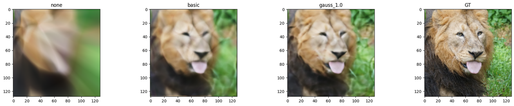

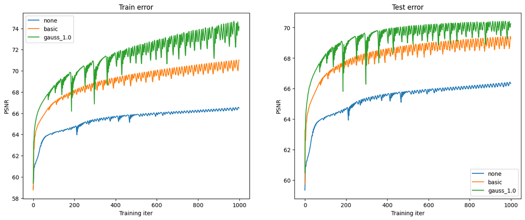

```python
X_train, y_train, X_test, y_test = get_input_features(B_dict, mapping="gauss_1.0")
size = 128
plot_feature_mapping_comparison(outputs, y_test.reshape(size,size,3))
```

#### High Resolution Reconstruction - Image of your Choice

When choosing an image select one that you think will give you interesting results or a better insight into the performance of different feature mappings and explain why in your report template.

[figure not shown]

```python
size = 128
# TODO pick an image and replace the url string
train_data, test_data = get_image(size, image_url="char.jpg")
```

```
Opt:Adam, lr:0.005
lr:0.005 epoch:1, Loss:0.2366138
Opt:Adam, lr:0.005
lr:0.005 epoch:2, Loss:0.0824868
Opt:Adam, lr:0.005
lr:0.005 epoch:3, Loss:0.0747591
Opt:Adam, lr:0.005
lr:0.005 epoch:4, Loss:0.0676575
Opt:Adam, lr:0.005
lr:0.005 epoch:5, Loss:0.0753794
Opt:Adam, lr:0.005
lr:0.005 epoch:6, Loss:0.0689984
Opt:Adam, lr:0.005
lr:0.005 epoch:7, Loss:0.0730113
Opt:Adam, lr:0.005
lr:0.005 epoch:8, Loss:0.0689819
Opt:Adam, lr:0.005
lr:0.005 epoch:9, Loss:0.0639452
Opt:Adam, lr:0.005
lr:0.005 epoch:10, Loss:0.0670853
Opt:Adam, lr:0.005
lr:0.005 epoch:11, Loss:0.0654825
Opt:Adam, lr:0.005
lr:0.005 epoch:12, Loss:0.0635298
Opt:Adam, lr:0.005
lr:0.005 epoch:13, Loss:0.0650966
Opt:Adam, lr:0.005
lr:0.005 epoch:14, Loss:0.0638805
Opt:Adam, lr:0.005
lr:0.005 epoch:15, Loss:0.0624925
Opt:Adam, lr:0.005
lr:0.005 epoch:16, Loss:0.0639329
Opt:Adam, lr:0.005
lr:0.005 epoch:17, Loss:0.0619013
Opt:Adam, lr:0.005
lr:0.005 epoch:18, Loss:0.0604598
Opt:Adam, lr:0.005
lr:0.005 epoch:19, Loss:0.0613918
Opt:Adam, lr:0.005
lr:0.005 epoch:20, Loss:0.0611994
```

[output cut: 1945 more lines]

```
lr:0.005 epoch:993, Loss:0.0086319
Opt:Adam, lr:0.005
lr:0.005 epoch:994, Loss:0.0079940
Opt:Adam, lr:0.005
lr:0.005 epoch:995, Loss:0.0076255
Opt:Adam, lr:0.005
lr:0.005 epoch:996, Loss:0.0074850
Opt:Adam, lr:0.005
lr:0.005 epoch:997, Loss:0.0076173
Opt:Adam, lr:0.005
lr:0.005 epoch:998, Loss:0.0078035
Opt:Adam, lr:0.005
lr:0.005 epoch:999, Loss:0.0080857
Opt:Adam, lr:0.005
lr:0.005 epoch:1000, Loss:0.0084457
```

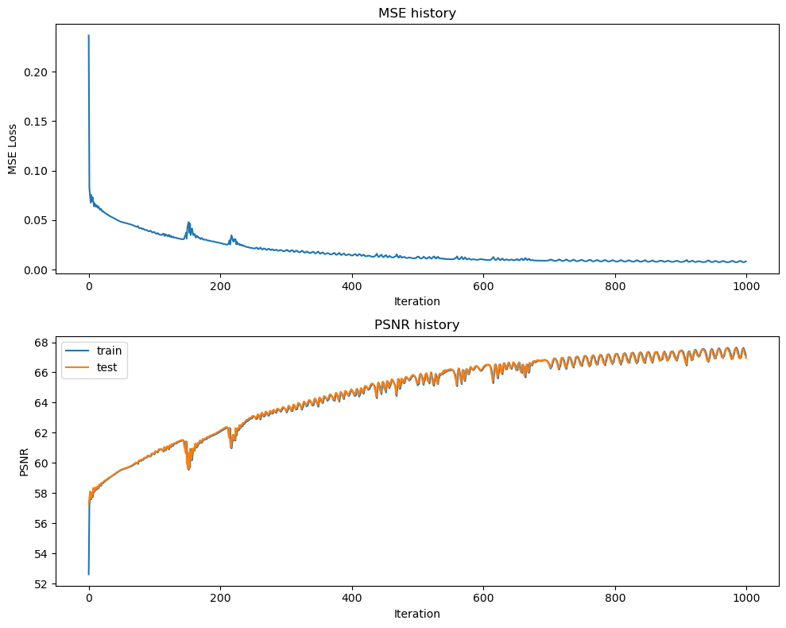

```
Final Test MSE 0.013155602061624744
Final Test psnr 66.9396963265309
```

[figure not shown]

```python
# get input features
# TODO implement this by using the get_B_dict() and get_input_features() helper functions

B_dict = get_B_dict(size)
input_size = X_train.shape[1]
X_train, y_train, X_test, y_test = get_input_features(B_dict, mapping="none")
# opt="Adam"
# run NN experiment on input features
# TODO implement by using the NN_experiment() helper function
opt = 'Adam'
learning_rate = 0.005
# epochs = 1000
# num_layers = 6
# hidden_size = 512
# hidden_sizes = [hidden_size] * (num_layers - 1)
# output_size = 3

net, train_psnr, test_psnr, train_loss, predicted_images = NN_experiment(
                        X_train, y_train, X_test, y_test, input_size, num_layers,\
                        hidden_size, hidden_sizes, output_size, epochs,\
                        learning_rate, opt)
plot_training_curves(train_loss, train_psnr, test_psnr)
plot_reconstruction(net.forward(X_test), y_test)
```

```
Opt:Adam, lr:0.005
lr:0.005 epoch:1, Loss:0.1960681
Opt:Adam, lr:0.005
lr:0.005 epoch:2, Loss:0.0684545
Opt:Adam, lr:0.005
lr:0.005 epoch:3, Loss:0.0605677
Opt:Adam, lr:0.005
lr:0.005 epoch:4, Loss:0.0630529
Opt:Adam, lr:0.005
lr:0.005 epoch:5, Loss:0.0537292
Opt:Adam, lr:0.005
lr:0.005 epoch:6, Loss:0.0536549
Opt:Adam, lr:0.005
lr:0.005 epoch:7, Loss:0.0476530
Opt:Adam, lr:0.005
lr:0.005 epoch:8, Loss:0.0433445
Opt:Adam, lr:0.005
lr:0.005 epoch:9, Loss:0.0448913
Opt:Adam, lr:0.005
lr:0.005 epoch:10, Loss:0.0405873
Opt:Adam, lr:0.005
lr:0.005 epoch:11, Loss:0.0369710
Opt:Adam, lr:0.005
lr:0.005 epoch:12, Loss:0.0372494
Opt:Adam, lr:0.005
lr:0.005 epoch:13, Loss:0.0360478
Opt:Adam, lr:0.005
lr:0.005 epoch:14, Loss:0.0349314
Opt:Adam, lr:0.005
lr:0.005 epoch:15, Loss:0.0330800
Opt:Adam, lr:0.005
lr:0.005 epoch:16, Loss:0.0303118
Opt:Adam, lr:0.005
lr:0.005 epoch:17, Loss:0.0297948
Opt:Adam, lr:0.005
lr:0.005 epoch:18, Loss:0.0296113
Opt:Adam, lr:0.005
lr:0.005 epoch:19, Loss:0.0286220
Opt:Adam, lr:0.005
lr:0.005 epoch:20, Loss:0.0275518
```

[output cut: 1945 more lines]

```
lr:0.005 epoch:993, Loss:0.0020424
Opt:Adam, lr:0.005
lr:0.005 epoch:994, Loss:0.0025411
Opt:Adam, lr:0.005
lr:0.005 epoch:995, Loss:0.0026612
Opt:Adam, lr:0.005
lr:0.005 epoch:996, Loss:0.0026429
Opt:Adam, lr:0.005
lr:0.005 epoch:997, Loss:0.0020918
Opt:Adam, lr:0.005
lr:0.005 epoch:998, Loss:0.0018877
Opt:Adam, lr:0.005
lr:0.005 epoch:999, Loss:0.0020249
Opt:Adam, lr:0.005
lr:0.005 epoch:1000, Loss:0.0023128
```

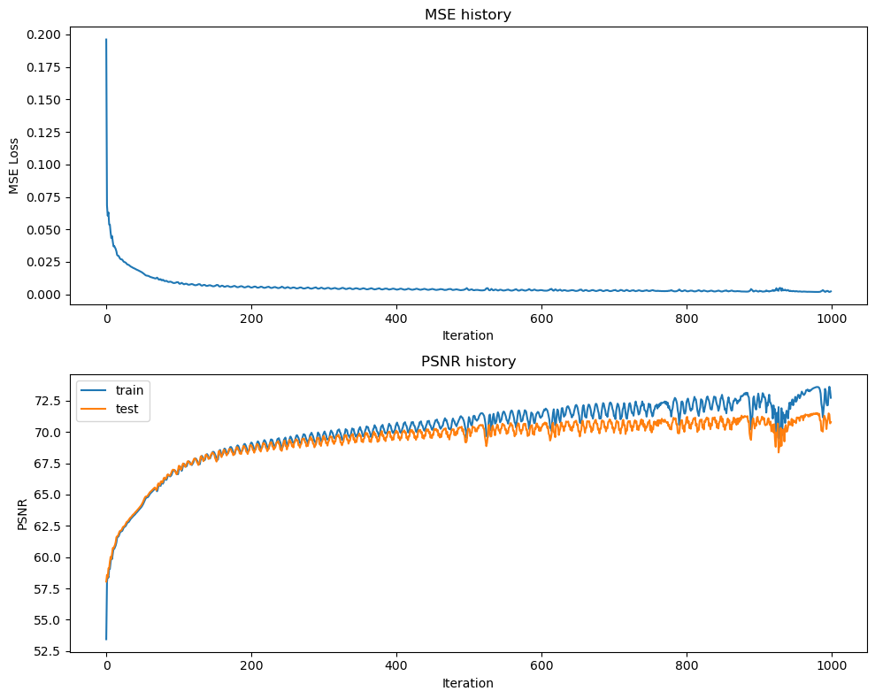

```
Final Test MSE 0.0054232812388363355
Final Test psnr 70.78818234339941
```

[figure not shown]

```python
# get input features
# TODO implement this by using the get_B_dict() and get_input_features() helper functions

B_dict = get_B_dict(size)
input_size = X_train.shape[1]
X_train, y_train, X_test, y_test = get_input_features(B_dict, mapping="basic")
# opt="Adam"
# run NN experiment on input features
# TODO implement by using the NN_experiment() helper function
opt = 'Adam'
learning_rate = 0.005
# epochs = 1000
# num_layers = 6
# hidden_size = 512
# hidden_sizes = [hidden_size] * (num_layers - 1)
# output_size = 3

net, train_psnr, test_psnr, train_loss, predicted_images = NN_experiment(
                        X_train, y_train, X_test, y_test, input_size, num_layers,\
                        hidden_size, hidden_sizes, output_size, epochs,\
                        learning_rate, opt)
plot_training_curves(train_loss, train_psnr, test_psnr)
plot_reconstruction(net.forward(X_test), y_test)
```

```
Opt:Adam, lr:0.005
lr:0.005 epoch:1, Loss:0.1952834
Opt:Adam, lr:0.005
lr:0.005 epoch:2, Loss:0.0693405
Opt:Adam, lr:0.005
lr:0.005 epoch:3, Loss:0.0595064
Opt:Adam, lr:0.005
lr:0.005 epoch:4, Loss:0.0607859
Opt:Adam, lr:0.005
lr:0.005 epoch:5, Loss:0.0456922
Opt:Adam, lr:0.005
lr:0.005 epoch:6, Loss:0.0449188
Opt:Adam, lr:0.005
lr:0.005 epoch:7, Loss:0.0380166
Opt:Adam, lr:0.005
lr:0.005 epoch:8, Loss:0.0323549
Opt:Adam, lr:0.005
lr:0.005 epoch:9, Loss:0.0333568
Opt:Adam, lr:0.005
lr:0.005 epoch:10, Loss:0.0320497
Opt:Adam, lr:0.005
lr:0.005 epoch:11, Loss:0.0288347
Opt:Adam, lr:0.005
lr:0.005 epoch:12, Loss:0.0276129
Opt:Adam, lr:0.005
lr:0.005 epoch:13, Loss:0.0268749
Opt:Adam, lr:0.005
lr:0.005 epoch:14, Loss:0.0250887
Opt:Adam, lr:0.005
lr:0.005 epoch:15, Loss:0.0229070
Opt:Adam, lr:0.005
lr:0.005 epoch:16, Loss:0.0216000
Opt:Adam, lr:0.005
lr:0.005 epoch:17, Loss:0.0208965
Opt:Adam, lr:0.005
lr:0.005 epoch:18, Loss:0.0196279
Opt:Adam, lr:0.005
lr:0.005 epoch:19, Loss:0.0183335
Opt:Adam, lr:0.005
lr:0.005 epoch:20, Loss:0.0179470
```

[output cut: 1945 more lines]

```
lr:0.005 epoch:993, Loss:0.0005665
Opt:Adam, lr:0.005
lr:0.005 epoch:994, Loss:0.0006521
Opt:Adam, lr:0.005
lr:0.005 epoch:995, Loss:0.0008892
Opt:Adam, lr:0.005
lr:0.005 epoch:996, Loss:0.0004722
Opt:Adam, lr:0.005
lr:0.005 epoch:997, Loss:0.0006480
Opt:Adam, lr:0.005
lr:0.005 epoch:998, Loss:0.0007559
Opt:Adam, lr:0.005
lr:0.005 epoch:999, Loss:0.0004505
Opt:Adam, lr:0.005
lr:0.005 epoch:1000, Loss:0.0005829
```

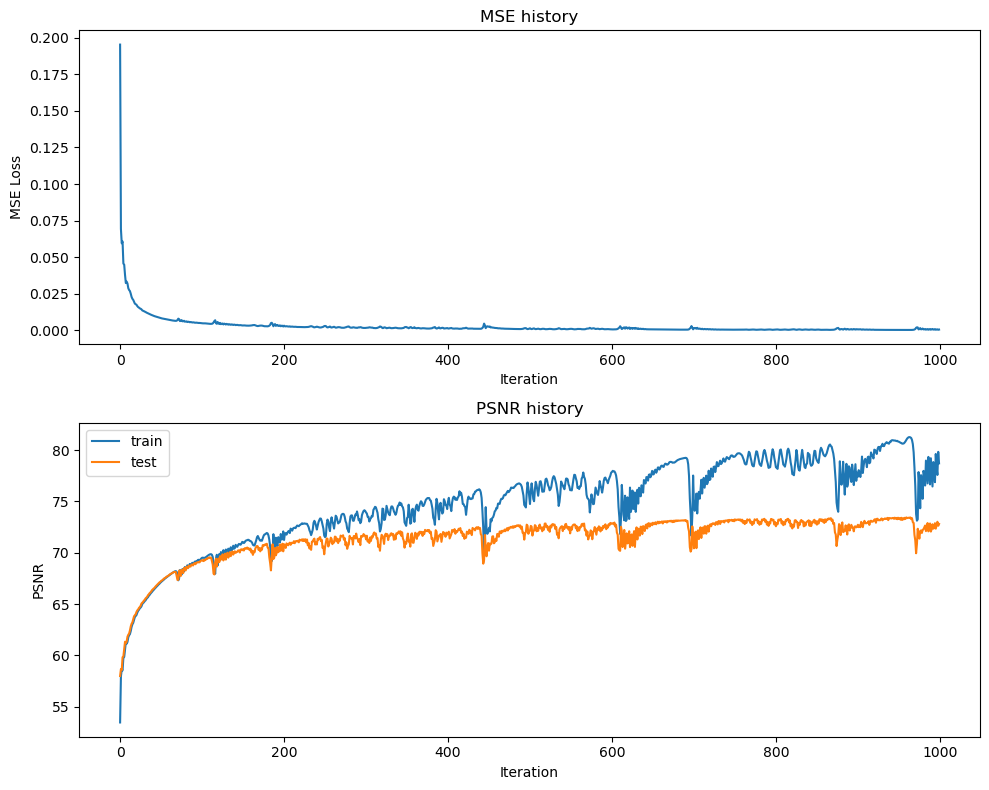

```
Final Test MSE 0.003404866841469704
Final Test psnr 72.80980228802873
```

[figure not shown]

```python
# get input features
# TODO implement this by using the get_B_dict() and get_input_features() helper functions

B_dict = get_B_dict(size)
input_size = X_train.shape[1]
X_train, y_train, X_test, y_test = get_input_features(B_dict, mapping="gauss_1.0")
# opt="Adam"
# run NN experiment on input features
# TODO implement by using the NN_experiment() helper function
opt = 'Adam'
learning_rate = 0.005
# epochs = 1000
# num_layers = 6
# hidden_size = 512
# hidden_sizes = [hidden_size] * (num_layers - 1)
# output_size = 3

net, train_psnr, test_psnr, train_loss, predicted_images = NN_experiment(
                        X_train, y_train, X_test, y_test, input_size, num_layers,\
                        hidden_size, hidden_sizes, output_size, epochs,\
                        learning_rate, opt)
plot_training_curves(train_loss, train_psnr, test_psnr)
plot_reconstruction(net.forward(X_test), y_test)
```

# Reconstruction Process Video (Optional)

(For Fun!) Visualize the progress of training in a video

```python
# requires installing this additional dependency
# !pip install imageio-ffmpeg
```

```python
# single video example
create_and_visualize_video({"gauss": {"pred_imgs": predicted_images}}, size=32, filename="training_high_res_gauss.mp4")
```

[output not shown]

```python
# multi video example
create_and_visualize_video(outputs, epochs=1000, size=32)
```

[output not shown]